# Week 8 - Homework

STAT 420, Summer 2020, Hyunjoon Rhee

# Directions

Students are encouraged to work together on homework. However, sharing, copying or providing any part of a homework solution or code is an infraction of the University’s rules on Academic Integrity. Any violation will be punished as severely as possible.

- Be sure to remove this section if you use this `.Rmd` file as a template.
- You may leave the questions in your final document.

## Exercise 1 (Writing Functions)

**(a)** Write a function named `diagnostics` that takes as input the arguments:

- `model`, an object of class `lm()`, that is a model fit via `lm()`
- `pcol`, for controlling point colors in plots, with a default value of `grey`
- `lcol`, for controlling line colors in plots, with a default value of `dodgerblue`
- `alpha`, the significance level of any test that will be performed inside the function, with a default value of `0.05`
- `plotit`, a logical value for controlling display of plots with default value `TRUE`
- `testit`, a logical value for controlling outputting the results of tests with default value `TRUE`

The function should output:

- A list with two elements when `testit` is `TRUE`:
  - `p_val`, the p-value for the Shapiro-Wilk test for assessing normality
  - `decision`, the decision made when performing the Shapiro-Wilk test using the `alpha` value input to the function. “Reject” if the null hypothesis is rejected, otherwise “Fail to Reject.”
- Two plots, side-by-side, when `plotit` is `TRUE`:
  - A fitted versus residuals plot that adds a horizontal line at $y = 0$, and labels the $x$-axis “Fitted” and the $y$-axis “Residuals.” The points and line should be colored according to the input arguments. Give the plot a title.
  - A Normal Q-Q plot of the residuals that adds the appropriate line using `qqline()`. The points and line should be colored according to the input arguments. Be sure the plot has a title.

Consider using this function to help with the remainder of the assignment as well.

```r
library(ggplot2)
diagnostics = function(model, pcol = "grey", lcol = "dodgerblue", alpha = 0.05,
                       plotit = TRUE, testit = TRUE) {
  if(testit == TRUE) {
    p_val = shapiro.test(resid(model))$p.value
    if(p_val < alpha) {
      decision = "Reject"
    } else {
      decision = "Fail to Reject"
    }
    print(list(p_val, decision))
  }
  if(plotit == TRUE) {
    par(mfrow = c(1, 2))
    plot(fitted(model), resid(model), col = pcol, pch = 20, xlab = "Fitted", ylab = "Residuals", main = "Fitted vs Residual")
    abline(h = 0, col = lcol, lwd = 2)
    grid()
    qqnorm(resid(model), col = pcol, pch = 20)
    qqline(resid(model), col = lcol, lwd = 2)
    grid()
  }
}
```

**(b)** Run the following code.

```r
set.seed(40)

data_1 = data.frame(x = runif(n = 30, min = 0, max = 10),
                    y = rep(x = 0, times = 30))
data_1$y = with(data_1, 2 + 1 * x + rexp(n = 30))
fit_1 = lm(y ~ x, data = data_1)

data_2 = data.frame(x = runif(n = 20, min = 0, max = 10),
                    y = rep(x = 0, times = 20))
data_2$y = with(data_2, 5 + 2 * x + rnorm(n = 20))
fit_2 = lm(y ~ x, data = data_2)

data_3 = data.frame(x = runif(n = 40, min = 0, max = 10),
                    y = rep(x = 0, times = 40))
data_3$y = with(data_3, 2 + 1 * x + rnorm(n = 40, sd = x))
fit_3 = lm(y ~ x, data = data_3)
```

```r
diagnostics(fit_1, plotit = FALSE)$p_val
```

```
## [[1]]
## [1] 0.005613
##
## [[2]]
## [1] "Reject"
```

```r
diagnostics(fit_2, plotit = FALSE)$decision
```

```
## [[1]]
## [1] 0.6415
##
## [[2]]
## [1] "Fail to Reject"
```

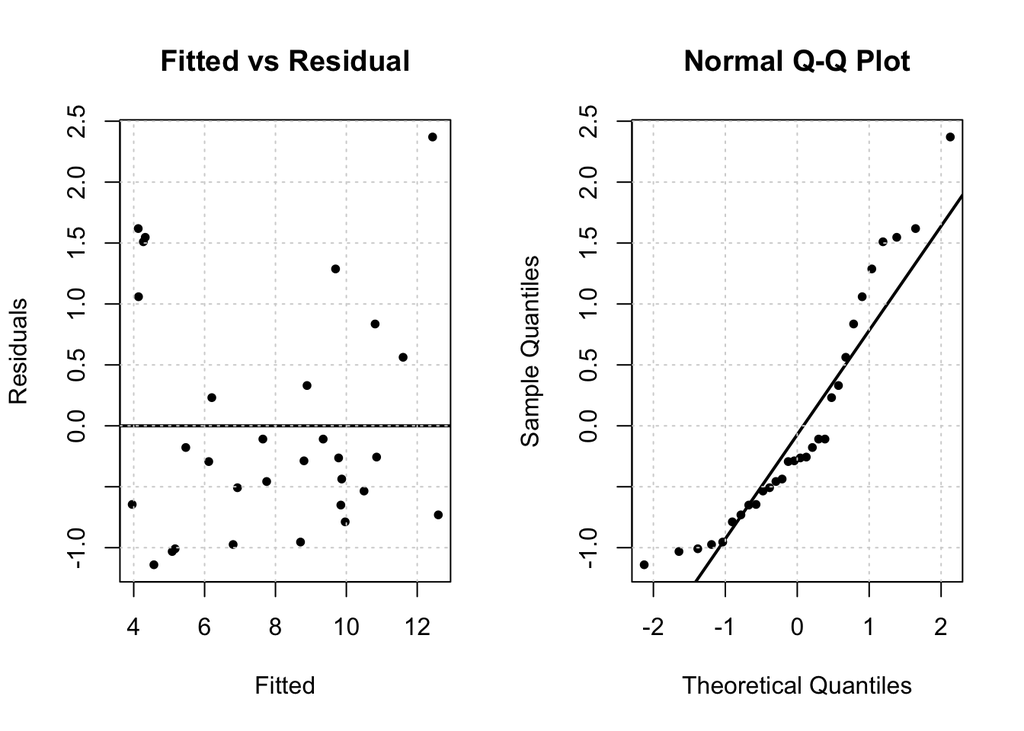

```r
diagnostics(fit_1, testit = FALSE, pcol = "black", lcol = "black")
```

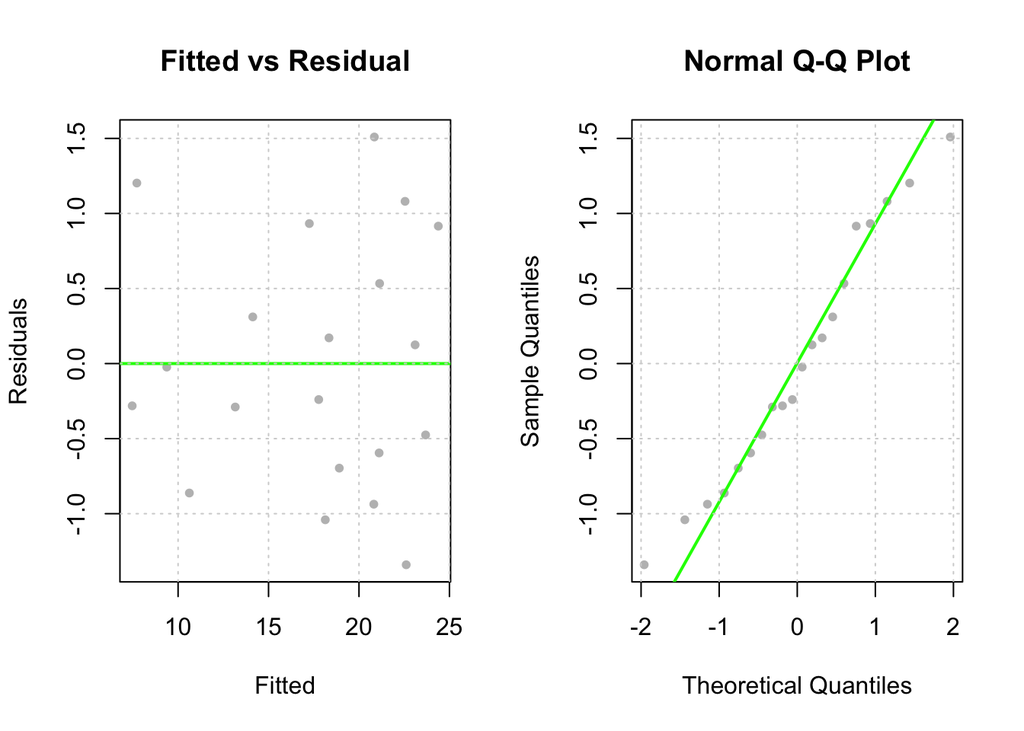

```r
diagnostics(fit_2, testit = FALSE, pcol = "grey", lcol = "green")
```

```r
diagnostics(fit_3)
```

```
## [[1]]
## [1] 0.001608
##
## [[2]]
## [1] "Reject"
```

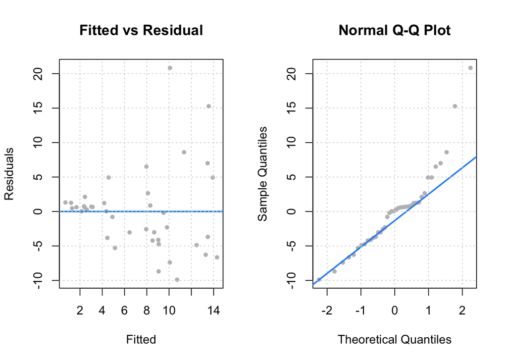

## Exercise 2 (Prostate Cancer Data)

For this exercise, we will use the `prostate` data, which can be found in the `faraway` package. After loading the `faraway` package, use `?prostate` to learn about this dataset.

```r
library(faraway)
```

**(a)** Fit an additive multiple regression model with `lpsa` as the response and the remaining variables in the `prostate` dataset as predictors. Report the $R^2$ value for this model.

```r
a = lm(lpsa ~ ., data = prostate)
summary(a)$r.squared
```

```
## [1] 0.6548
```

**(b)** Check the constant variance assumption for this model. Do you feel it has been violated? Justify your answer.

```r
library(lmtest)
diagnostics(a)
```

```
## [[1]]
## [1] 0.7721
##
## [[2]]
## [1] "Fail to Reject"
```

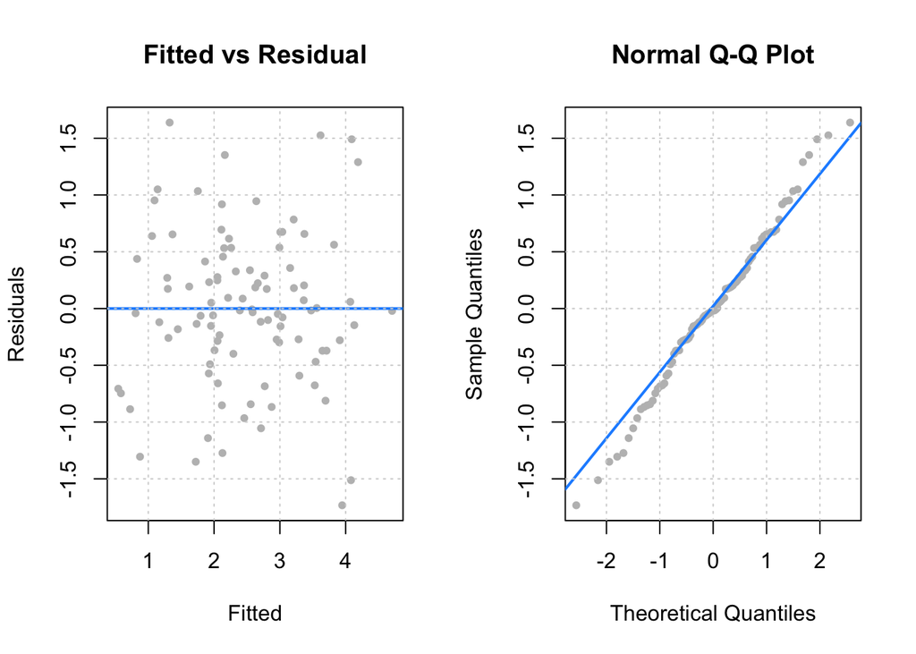

```r
bptest(a)
```

```
##
##  studentized Breusch-Pagan test
##
## data:  a
## BP = 10, df = 8, p-value = 0.3
```

According to the “Fitted vs Residual” graph, mean of residuals is seemingly near to 0. Also, the spread of residuals seem even. Moreover, due to the p value which seems to be not small, it fails to reject the null of homoscedasticity, meaning it is not violated.

**(c)** Check the normality assumption for this model. Do you feel it has been violated? Justify your answer.

The graph of “QQplot” looks like the points are pretty close to the line. This shows the data, with a high chance, are sampled from normal distribution. Also because the Shapiro test fails to reject, it seems that it is not violated.

**(d)** Check for any high leverage observations. Report any observations you determine to have high leverage.

```r
a_lev = hatvalues(a)
a_lev[a_lev > 2 * mean(a_lev)]
```

```
##     32     37     41     74     92
## 0.3305 0.2184 0.2410 0.1912 0.2092
```

These are the points of high leverage.

**(e)** Check for any influential observations. Report any observations you determine to be influential.

```r
e = cooks.distance(a)
e[cooks.distance(a) > 4 / length(cooks.distance(a))]
```

```
##      32      39      47      69      95      96      97
## 0.12270 0.05202 0.10574 0.10054 0.09874 0.05594 0.07378
```

These are the points that are influential.

**(f)** Refit the additive multiple regression model without any points you identified as influential. Compare the coefficients of this fitted model to the previously fitted model.

```r
f = lm(lpsa ~ ., data = prostate, subset = e <= 4 / length(e))
all.equal(coef(summary(a)),coef(summary(f)))
```

```
## [1] "Mean relative difference: 0.2925"
```

This shows that there are some significant changes in coefficients of the fitted model.

**(g)** Create a data frame that stores the observations that were “removed” because they were influential. Use the two models you have fit to make predictions with these observations. Comment on the difference between these two sets of predictions.

```r
removed = data.frame(prostate[e > 4 / length(e), ])
g1 = predict(a,removed)
g2 = predict(f,removed)
all.equal(g1,g2)
```

```
## [1] "Mean relative difference: 0.04178"
```

The difference is very close to zero. But I would not say that it is not different because 0.04 could not be defined as small.

## Exercise 3 (Why Bother?)

**Why** do we care about violations of assumptions? One key reason is that the distributions of the parameter esimators that we have used are all reliant on these assumptions. When the assumptions are violated, the distributional results are not correct, so our tests are garbage. **Garbage In, Garbage Out!**

Consider the following setup that we will use for the remainder of the exercise. We choose a sample size of 50.

```r
n = 50
set.seed(420)
x_1 = runif(n, 0, 5)
x_2 = runif(n, -2, 2)
```

Consider the model,

$$Y = 4 + 1 x_1 + 0 x_2 + \epsilon.$$

That is,

- $\beta_0$ = 4
- $\beta_1$ = 1
- $\beta_2$ = 0

We now simulate `y_1` in a manner that does **not** violate any assumptions, which we will verify. In this case $\epsilon \sim N(0, 1).$

```r
set.seed(83)
library(lmtest)
simulate1 = function() {
y_1 = 4 + 1 * x_1 + 0 * x_2 + rnorm(n = n, mean = 0, sd = 1)
fit_1 = lm(y_1 ~ x_1 + x_2)
#bptest(fit_1)
return(coef(summary(fit_1))[3,4])
}
```

Then, we simulate `y_2` in a manner that **does** violate assumptions, which we again verify. In this case $\epsilon \sim N(0, \sigma = |x_2|).$

```r
set.seed(83)
simulate2 = function() {
y_2 = 4 + 1 * x_1 + 0 * x_2 + rnorm(n = n, mean = 0, sd = abs(x_2))
fit_2 = lm(y_2 ~ x_1 + x_2)
#bptest(fit_2)
return(coef(summary(fit_2))[3,4])
}
```

**(a)** Use the following code after changing `birthday` to your birthday.

```r
num_sims = 2500
p_val_1 = rep(0, num_sims)
p_val_2 = rep(0, num_sims)
birthday = 19960926
set.seed(birthday)
```

Repeat the above process of generating `y_1` and `y_2` as defined above, and fit models with each as the response `2500` times. Each time, store the p-value for testing,

$$\beta_2 = 0,$$

using both models, in the appropriate variables defined above. (You do not need to use a data frame as we have in the past. Although, feel free to modify the code to instead use a data frame.)

```r
for (i in 1:num_sims) {
  p_val_1[i] = simulate1()
  p_val_2[i] = simulate2()
}
```

**(b)** What proportion of the `p_val_1` values is less than 0.01? Less than 0.05? Less than 0.10? What proportion of the `p_val_2` values is less than 0.01? Less than 0.05? Less than 0.10? Arrange your results in a table. Briefly explain these results.

```r
library("knitr")
p1 = c(length(p_val_1[p_val_1 < 0.01])/length(p_val_1), length(p_val_1[p_val_1 < 0.05])/length(p_val_1), length(p_val_1[p_val_1 < 0.10])/length(p_val_1))
p2 = c(length(p_val_2[p_val_2 < 0.01])/length(p_val_2),
length(p_val_2[p_val_2 < 0.05])/length(p_val_2),
length(p_val_2[p_val_2 < 0.10])/length(p_val_2))
alpha = c(0.01,0.05,0.10)
result = data.frame(alpha,p1,p2)
result
```

```
##   alpha     p1     p2
## 1  0.01 0.0124 0.0352
## 2  0.05 0.0540 0.1068
## 3  0.10 0.1060 0.1676
```

```r
colnames(result) = c("val","p_val1","p_val2")
kable(result)
```

| val | p_val1 | p_val2 |
| --- | --- | --- |
| 0.01 | 0.0124 | 0.0352 |
| 0.05 | 0.0540 | 0.1068 |
| 0.10 | 0.1060 | 0.1676 |

## Exercise 4 (Corrosion Data)

For this exercise, we will use the `corrosion` data, which can be found in the `faraway` package. After loading the `faraway` package, use `?corrosion` to learn about this dataset.

```r
library(faraway)
```

**(a)** Fit a simple linear regression with `loss` as the response and `Fe` as the predictor. Plot a scatterplot and add the fitted line. Check the assumptions of this model.

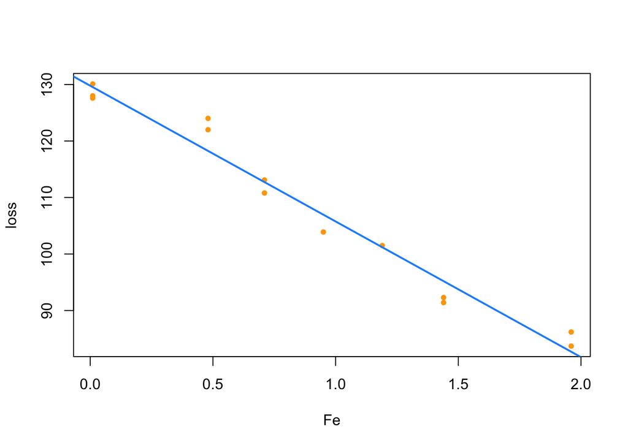

```r
corrosionmodel = lm(loss ~ Fe, data = corrosion)
plot(loss ~ Fe, data = corrosion, col = "orange", pch = 20)
abline(corrosionmodel, col = "dodgerblue", lwd = 2)
```

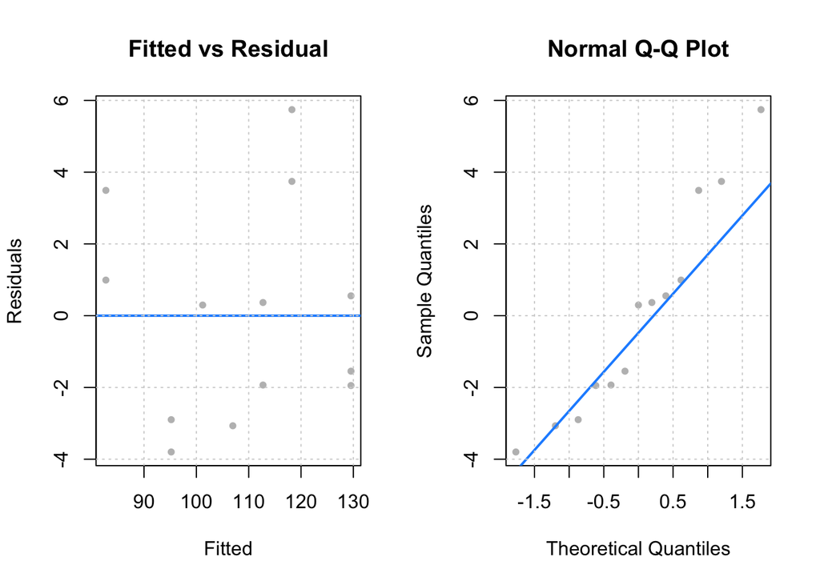

```r
diagnostics(corrosionmodel, testit = FALSE)
```

QQplot shows that the samples are almost similar but not exactly matching. The fitted vs residual graph seems to show that the residuals add up to zero, but there is no strong evidence to this due to the lack of data.

**(b)** Fit higher order polynomial models of degree 2, 3, and 4. For each, plot a fitted versus residuals plot and comment on the constant variance assumption. Based on those plots, which of these three models do you think are acceptable? Use a statistical test(s) to compare the models you just chose. Based on the test, which is preferred? Check the normality assumption of this model. Identify any influential observations of this model.

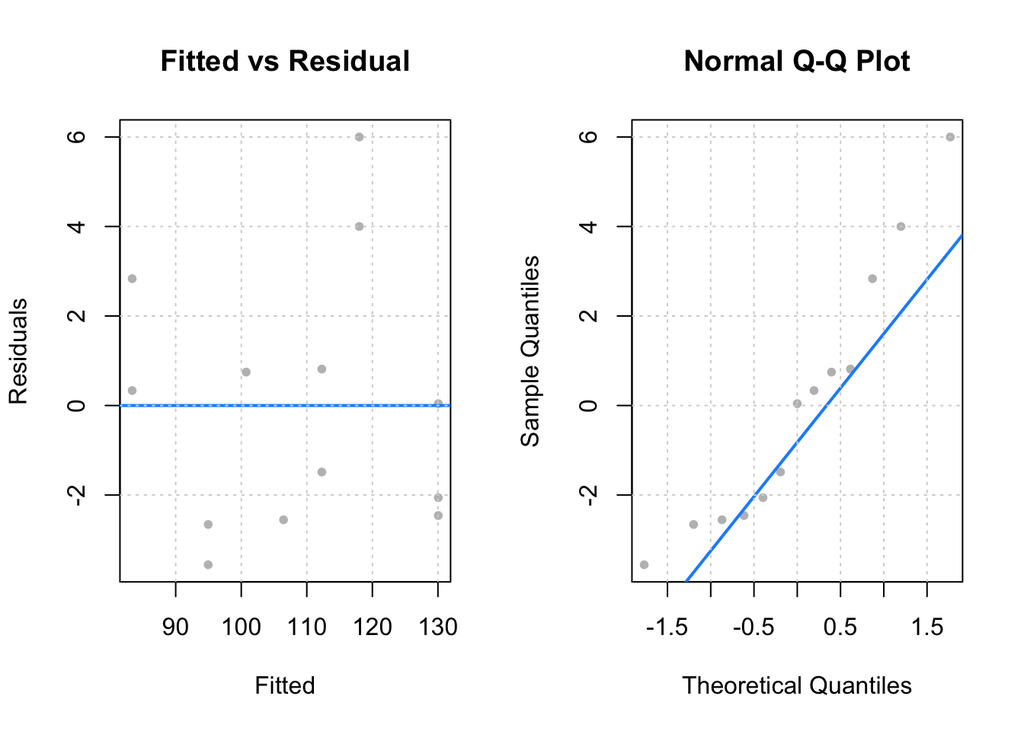

```r
corrosionmodel2 = lm(loss ~ poly(Fe, 2), data = corrosion)
diagnostics(corrosionmodel2, testit = FALSE)
```

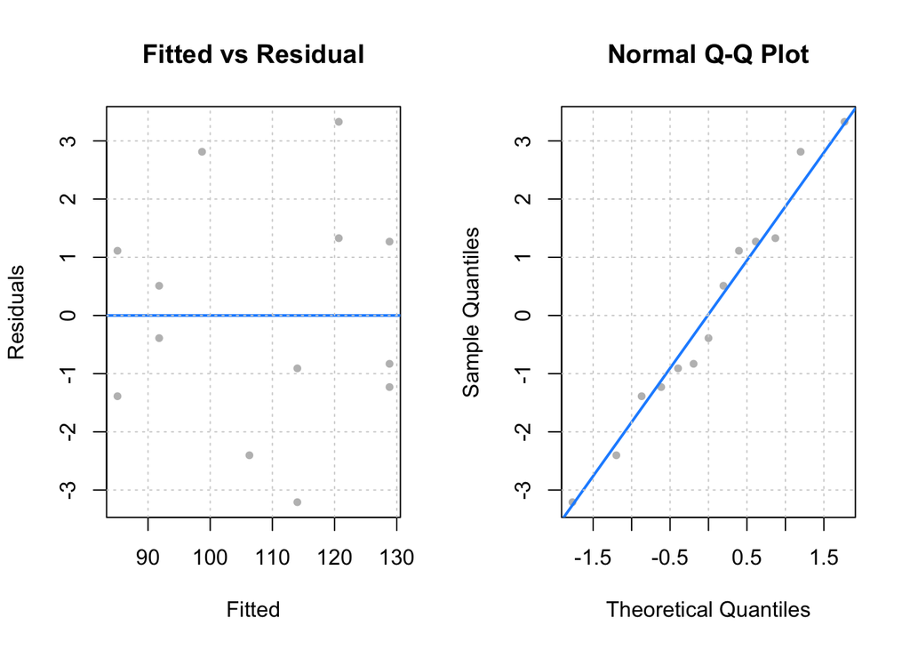

```r
corrosionmodel3 = lm(loss ~ poly(Fe, 3), data = corrosion)
diagnostics(corrosionmodel3, testit = FALSE)
```

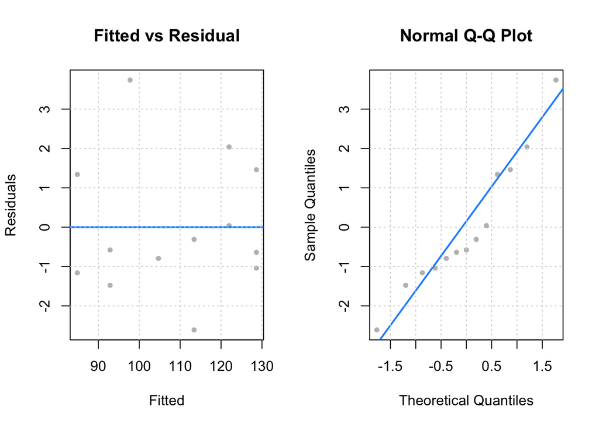

```r
corrosionmodel4 = lm(loss ~ poly(Fe, 4), data = corrosion)
diagnostics(corrosionmodel4, testit = FALSE)
```

The QQplot shows that model_3 and model_4 shows better fit compared to model_2.

```r
anova(corrosionmodel2, corrosionmodel3,corrosionmodel4)
```

```
## Analysis of Variance Table
##
## Model 1: loss ~ poly(Fe, 2)
## Model 2: loss ~ poly(Fe, 3)
## Model 3: loss ~ poly(Fe, 4)
##   Res.Df   RSS Df Sum of Sq    F Pr(>F)
## 1     10 100.1
## 2      9  45.1  1      55.0 12.6 0.0075 **
## 3      8  35.0  1      10.1  2.3 0.1675
## ---
## Signif. codes:  0 '***' 0.001 '**' 0.01 '*' 0.05 '.' 0.1 ' ' 1
```

```r
shapiro.test(resid(corrosionmodel3))
```

```
##
##  Shapiro-Wilk normality test
##
## data:  resid(corrosionmodel3)
## W = 0.97, p-value = 0.9
```

```r
corrtest = cooks.distance(corrosionmodel3)
corrtest[corrtest > 4 / length(corrtest)]
```

```
## named numeric(0)
```

The shapiro test shows that it fails to reject due to its pretty high p value. Also, the influential check has turned out there is no point that is influential.

## Exercise 5 (Diamonds)

The data set `diamonds` from the `ggplot2` package contains prices and characteristics of 54,000 diamonds. For this exercise, use `price` as the response variable $y$, and `carat` as the predictor $x$. Use `?diamonds` to learn more.

```r
library(ggplot2)
```

**(a)** Fit a linear model with `price` as the response variable $y$, and `carat` as the predictor $x$. Return the summary information of this model.

```r
dmodel = lm(price ~ carat, data = diamonds)
summary(dmodel)
```

```
##
## Call:
## lm(formula = price ~ carat, data = diamonds)
##
## Residuals:
##    Min     1Q Median     3Q    Max
## -18585   -805    -19    537  12732
##
## Coefficients:
##             Estimate Std. Error t value Pr(>|t|)
## (Intercept)  -2256.4       13.1    -173   <2e-16 ***
## carat         7756.4       14.1     551   <2e-16 ***
## ---
## Signif. codes:  0 '***' 0.001 '**' 0.01 '*' 0.05 '.' 0.1 ' ' 1
##
## Residual standard error: 1550 on 53938 degrees of freedom
## Multiple R-squared:  0.849,  Adjusted R-squared:  0.849
## F-statistic: 3.04e+05 on 1 and 53938 DF,  p-value: <2e-16
```

**(b)** Plot a scatterplot of price versus carat and add the line for the fitted model in part **(a)**. Using a fitted versus residuals plot and/or a Q-Q plot, comment on the diagnostics.

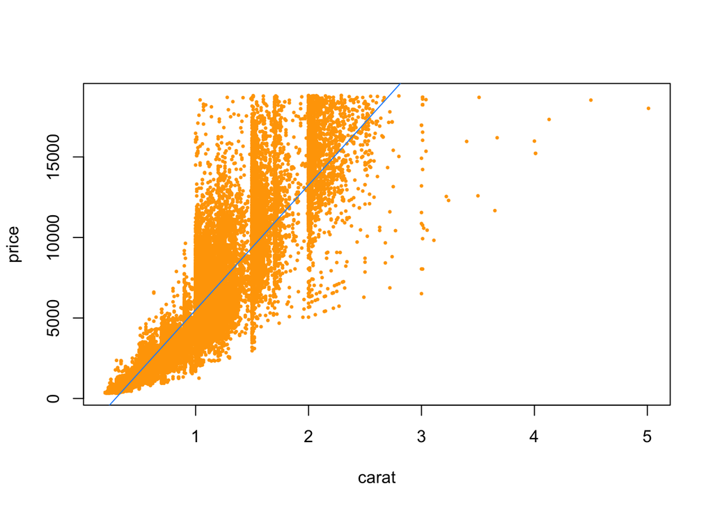

```r
plot(price ~ carat, data = diamonds, col = "orange",pch=20,cex = 0.5)
abline(dmodel, col = "dodgerblue")
```

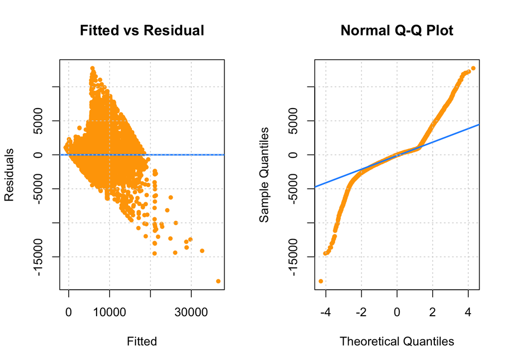

```r
diagnostics(dmodel,testit=FALSE,pcol='orange')
```

The diagnostic results the above. In ‘Fitted vs Residual’, it is hard to tell whether the sum of the residuals are about at zero, due to the number of data points in the graph. Whereas in QQplot, it seems that the data is not from normal distribution.

**(c)** Seeing as the price stretches over several orders of magnitude, it seems reasonable to try a log transformation of the response. Fit a model with a logged response, plot a scatterplot of log-price versus carat and add the line for the fitted model, then use a fitted versus residuals plot and/or a Q-Q plot to comment on the diagnostics of the model.

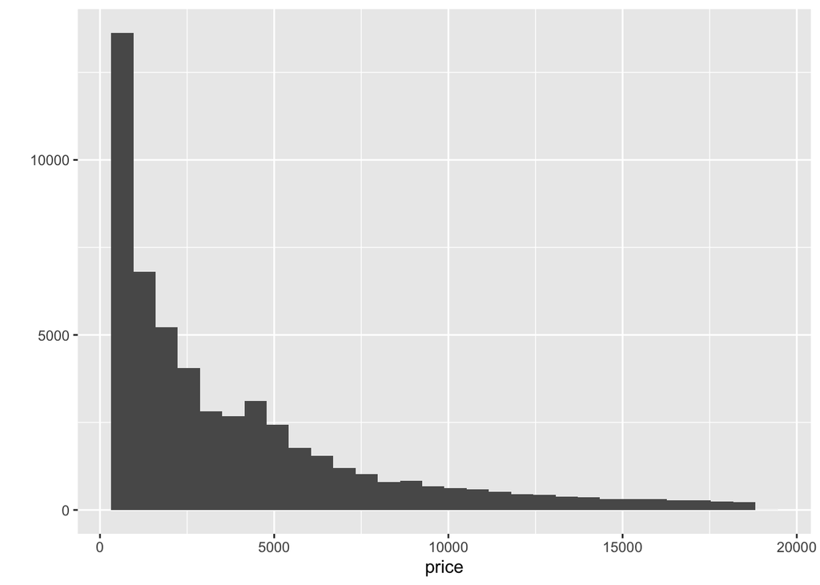

```r
qplot(price, data = diamonds, bins = 30)
```

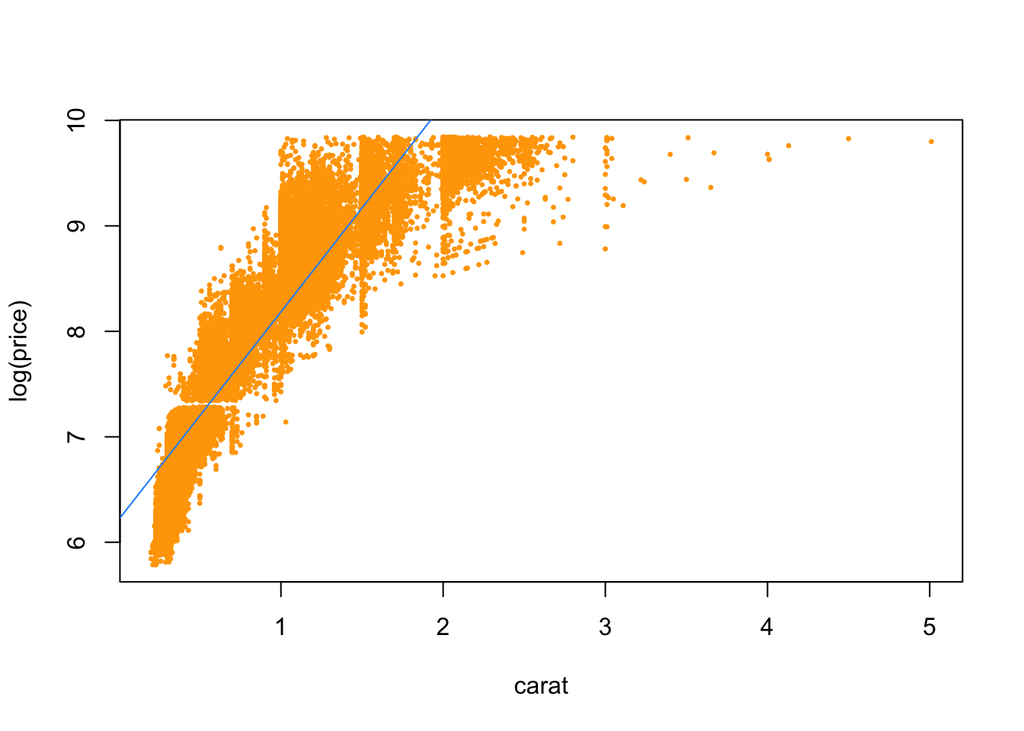

```r
dmodel2 = lm(log(price) ~ carat, data = diamonds)
plot(log(price) ~ carat, data = diamonds, col = "orange",pch=20,cex = 0.5)
abline(dmodel2, col = "dodgerblue")
```

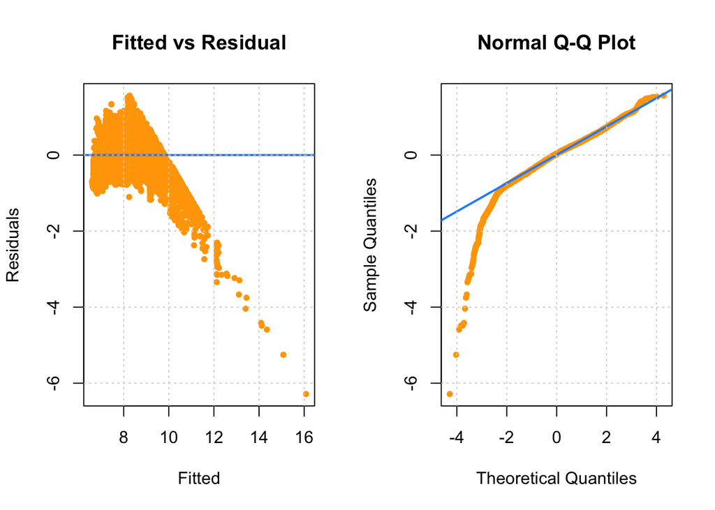

```r
diagnostics(dmodel2,pcol='orange',testit=FALSE)
```

In ‘Fitted vs Residual’, it is still hard to tell that if the sum of the residuals are to be zero. For QQplot, it is better than the plot before applying log, but it is still hard to conclude that the data is from normal distribution.

**(d)** Try adding log transformation of the predictor. Fit a model with a logged response and logged predictor, plot a scatterplot of log-price versus log-carat and add the line for the fitted model, then use a fitted versus residuals plot and/or a Q-Q plot to comment on the diagnostics of the model.

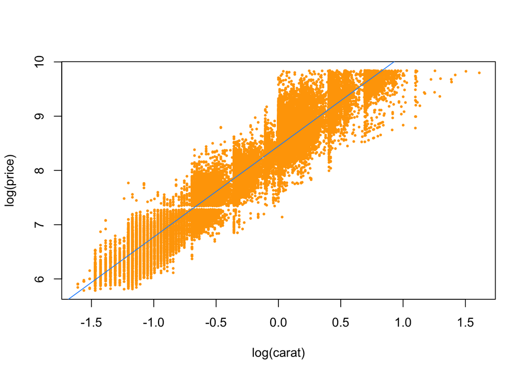

```r
dmodel3 = lm(log(price) ~ log(carat), data = diamonds)
plot(log(price) ~ log(carat), data = diamonds, col = "orange",pch=20,cex = 0.5)
abline(dmodel3, col = "dodgerblue")
```

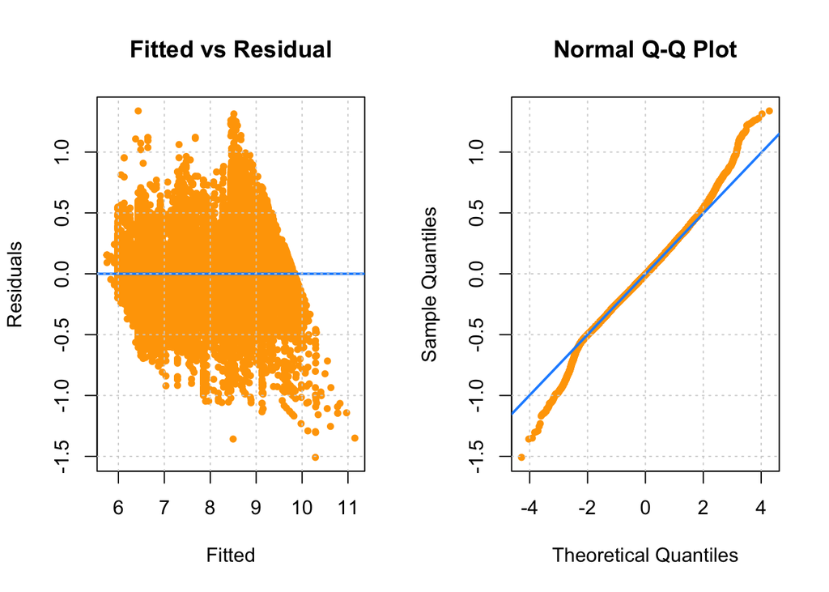

```r
diagnostics(dmodel3,pcol='orange',testit=FALSE)
```

In ‘Fitted vs Residual’, it shows that the residuals seem to add up to zero. For QQplot, the data diverge less from the line than before, which means that it is likely to be from normal distribution.

**(e)** Use the model from part **(d)** to predict the price (in dollars) of a 3-carat diamond. Construct a 99% prediction interval for the price (in dollars).

```r
exp(predict(dmodel3, newdata = data.frame("carat"=3)))
```

```
##     1
## 29429
```

```r
exp(predict(dmodel3, newdata = data.frame("carat"=3),level=0.99,interval="prediction"))
```

```
##     fit   lwr   upr
## 1 29429 14959 57894
```